# Forecasting the Evolution of Vancouver’s Business Landscape

2020/5/8

## Next 12 mins

- Why is this Important?
- Research Questions
- Datasets Overview
- Data Science Techniques
- Potential Difficulties
- Final Product
- Timeline

## Why is this Important?

- Individuals and Policy makers
- Post COVID-19 economy

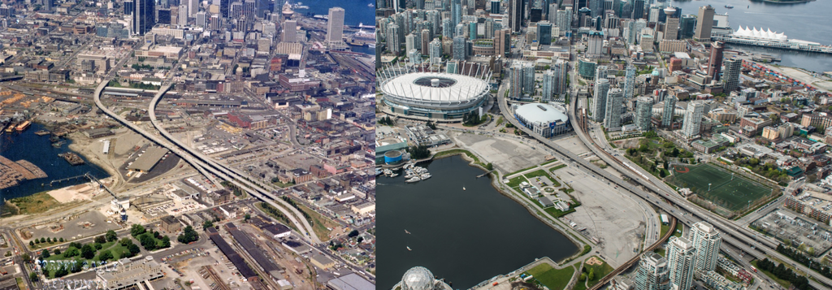

[Vancouver History](https://www.livabl.com/2013/07/vancouver-skyline.html)

## Research Questions

- Will a business renew their license in the coming year?
- Geospatial summary of Vancouver’s business landscape

## Dataset Overview

- **Licence dataset from 1997 to 2020**
  - Business type
  - Location
  - Number of employees

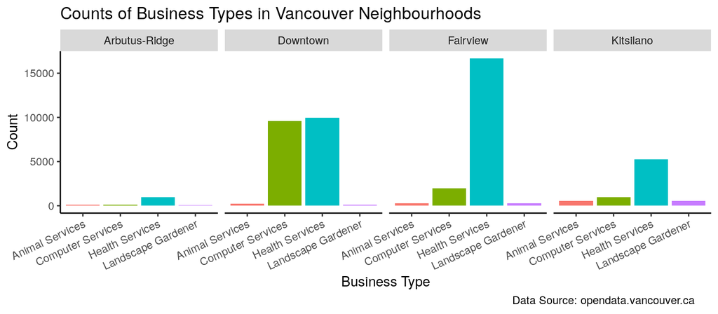

## Dataset Overview

- **Census local area profile**
  - Population density
  - Average household income
  - Average age group
  - Ethnicity

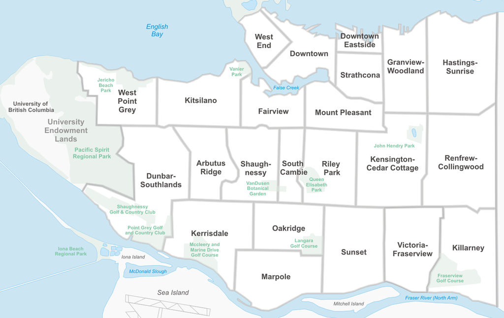

[Wikipedia Commons: Vancouver_2008.png](https://upload.wikimedia.org/wikipedia/commons/thumb/3/37/Stadtgliederung_Vancouver_2008.png/1200px-Stadtgliederung_Vancouver_2008.png)

## Potential Future Datasets

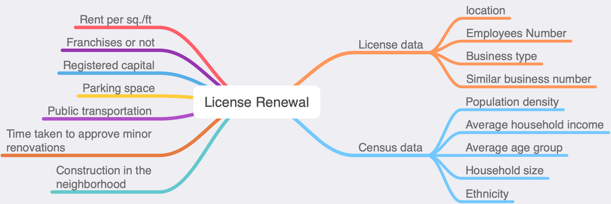

## Data Science Techniques

- Data synthesis
- Modeling using Postgres
- Baseline model:
  - Logistic regression
- Advance modeling:
  - Machine Learning and Simulations
- Further direction:
  - Survival analysis
- Geospatial visualization:
  - Python and Altair/Leaflet
- Deploy with Dash on Heroku

## Potential Difficulties

- Geospatial and temporal correlation between the variables
- Current variables may be proxies
  - Number of employees -> Capital invested
- Combine features from different data sources

## Final Product

- A data pipeline
- A geospatial visualization of Vancouver’s business landscape

[interactive chart not shown]

Descriptive and Simulated Information on Map

## Timeline (Week 1 - 2)

**Hackathon and Proposal**

| Capstone_Dates | Deliverable | Objectives |
| --- | --- | --- |
| May 4-8 |  | 1. Prepare proposal presentation 2. Setup GitHub repository |
| May 8 | Proposal Presentation |  |
| May 11-15 |  | 1. Prepare proposal report 2. EDA 3. Finalize form of final product |
| May 12 | Proposal Report to Mentor |  |
| May 15 | Proposal Report to Deetken |  |

## Timeline (Week 3 - 4)

**Launch Project, Develop ML Model, and Build Visualization**

| Capstone_Dates | Deliverable | Objectives |
| --- | --- | --- |
| May 18-22 |  | 1. Incorporate feedback on proposal 2. Launch project (modeling and visualization) |
| May 20 | Meeting with Deetken |  |
| May 25-29 |  | 1. Develop machine learning model 2. Develop geo-spatial visualization |

## Timeline (Week 5 - 6)

**Fine-tuning**

| Capstone_Dates | Deliverable | Objectives |
| --- | --- | --- |
| Jun 1-12 |  | 1. Fine-tuning of model and visualization 2. Update documentations or user manual for the end product |

## Timeline (Week 7 - 9)

**Final Stage**

| Capstone_Dates | Deliverable | Objectives |
| --- | --- | --- |
| Jun 18-19 | Final Presentation | Prepare for final presentation |
| Jun 22-26 |  | Prepare final report |
| Jun 23 | Final Report and Product to Mentor | Modify based on feedback from mentor |
| Jun 29 | Final Report and Product to Deetken | Final presentation to Deetken |
| Jun 30 | Teamwork Reflection |  |

## Thank you!

**Questions?**